# Projet 3

Simulation de portefeuilles et analyse du risque : Portefeuille de 2 ou 3 titres. Comparer la vraie VaR à celle obtenue lorsque la copule reliant ces deux ou trois titres est à faible dépendance en queue gauche (dans ce dernier cas, le portefeuille est simulé à partir de cette copule et des marginales).

Dans ce projet, nous allons nous intéresser à la structure de dépendance entre deux titres. Deux plutôt que trois pour une visualisation plus facile. En tant qu'alternant à CACF, j'ai fait le choix de CA et BNP.

**Récupération des données**

```python
!pip install copulae
```

```
     |████████████████████████████████| 1.6MB 2.9MB/s
```

```python
!pip install scipy==1.2 --upgrade
```

[output not shown]

```python
import os

import numpy as np
import pandas as pd
import matplotlib.pyplot as plt
import seaborn as sns
import copulae
```

```python
os.listdir("../input")
```

```
['CAC 40.xlsx']
```

```python
data = pd.read_excel("../input/CAC 40.xlsx")
```

```python
data.head()
```

|  | ISIN | JOUR | OUVR | PHAUT | PBAS | CLOT | Volume | NOM | TICKER |
| --- | --- | --- | --- | --- | --- | --- | --- | --- | --- |
| 0 | BE0003470755 | 2015-10-20 | 94.18 | 95.45 | 92.25 | 95.12 | 375579.0 | Solvay | SOLB |
| 1 | BE0003470755 | 2015-10-21 | 95.54 | 96.24 | 94.05 | 95.46 | 282786.0 | Solvay | SOLB |
| 2 | BE0003470755 | 2015-10-22 | 95.50 | 99.42 | 95.10 | 99.35 | 551677.0 | Solvay | SOLB |
| 3 | BE0003470755 | 2015-10-23 | 100.65 | 104.55 | 100.65 | 101.85 | 569759.0 | Solvay | SOLB |
| 4 | BE0003470755 | 2015-10-26 | 101.85 | 102.25 | 100.20 | 100.85 | 283484.0 | Solvay | SOLB |

```python
data_clot = data.set_index(["JOUR","NOM"],append=False)["CLOT"]
data_clot.head()
```

```
JOUR        NOM
2015-10-20  Solvay     95.12
2015-10-21  Solvay     95.46
2015-10-22  Solvay     99.35
2015-10-23  Solvay    101.85
2015-10-26  Solvay    100.85
Name: CLOT, dtype: float64
```

```python
data_clot = data_clot.unstack(level="NOM")
data_clot.head()
```

| NOM JOUR | Accor Hotels | Air Liquide | Airbus | Arcelor Mittal | Atos | Axa | Bnp Paribas | Bouygues | CAC40 | Cap Gemini | Carrefour | Credit Agricole | Danone | Engie | Essilor Intl | Kering | L'oreal | LafargeHolcim | Legrand SA | Lvmh | Michelin | Orange | Pernod Ricard | Peugeot | Publicis Groupe | Renault | Safran | Saint Gobain | Sanofi | … |
| --- | --- | --- | --- | --- | --- | --- | --- | --- | --- | --- | --- | --- | --- | --- | --- | --- | --- | --- | --- | --- | --- | --- | --- | --- | --- | --- | --- | --- | --- | --- |
| 2015-10-20 | 42.500 | 99.0909 | 55.03 | 15.924 | 69.59 | 22.915 | 54.30 | 33.970 | 4673.81 | 78.41 | 28.655 | 11.050 | 59.00 | 15.260 | 110.70 | 150.00 | 167.55 | 49.77 | 46.890 | 158.30 | 84.97 | 14.315 | 98.89 | 15.140 | 64.53 | 78.04 | 69.14 | 37.080 | 87.29 | … |
| 2015-10-21 | 42.850 | 99.6818 | 56.28 | 15.810 | 70.48 | 23.095 | 54.40 | 34.290 | 4695.10 | 78.45 | 28.710 | 11.000 | 60.02 | 15.465 | 110.75 | 151.55 | 165.65 | 49.77 | 47.605 | 158.05 | 85.65 | 14.390 | 98.51 | 15.420 | 62.44 | 78.92 | 69.44 | 37.540 | 87.00 | … |
| 2015-10-22 | 44.265 | 103.0455 | 57.52 | 16.170 | 71.22 | 23.820 | 55.01 | 34.690 | 4802.18 | 79.79 | 29.600 | 11.155 | 61.95 | 15.810 | 112.85 | 156.20 | 171.00 | 50.55 | 48.505 | 165.15 | 87.09 | 15.475 | 103.65 | 15.845 | 58.05 | 81.17 | 69.01 | 38.035 | 89.23 | … |
| 2015-10-23 | 45.090 | 105.3636 | 60.17 | 16.380 | 73.00 | 24.050 | 55.91 | 35.175 | 4923.64 | 82.45 | 30.200 | 11.460 | 63.15 | 16.240 | 116.45 | 172.75 | 173.60 | 52.41 | 50.450 | 170.65 | 90.80 | 15.930 | 106.45 | 16.230 | 59.91 | 82.72 | 70.34 | 39.575 | 92.45 | … |
| 2015-10-26 | 44.930 | 105.8182 | 59.95 | 16.032 | 72.93 | 24.155 | 55.85 | 35.190 | 4897.13 | 82.27 | 29.950 | 11.590 | 63.17 | 16.100 | 116.40 | 170.00 | 171.00 | 52.30 | 50.200 | 169.15 | 90.27 | 16.030 | 105.50 | 15.640 | 60.00 | 81.84 | 69.49 | 39.140 | 91.85 | … |

```python
ca_clot = data_clot["Credit Agricole"]
bnp_clot = data_clot["Bnp Paribas"]
```

```python
ca_returns = np.log(ca_clot/ca_clot.shift()).dropna()
bnp_returns = np.log(bnp_clot/bnp_clot.shift()).dropna()
```

**Exploration des données**

Regardons à quoi ressemble les rendements de nos titres.

Tout d'abord, voici les rendements individuels

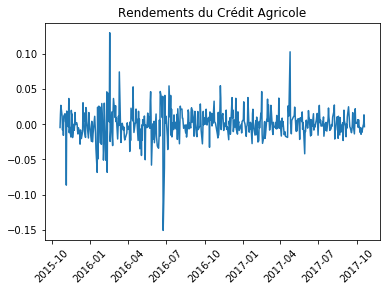

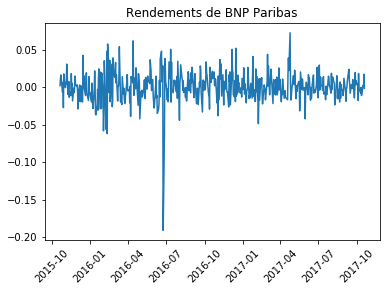

```python
plt.plot(ca_returns)
plt.title("Rendements du Crédit Agricole")
plt.xticks(rotation=45)
plt.show()

plt.plot(bnp_returns)
plt.title("Rendements de BNP Paribas")
plt.xticks(rotation=45)
plt.show()
```

Les rendements du Crédit Agricole sont plus volatils. Les chocs sur ces rendements semblent être corrélés.

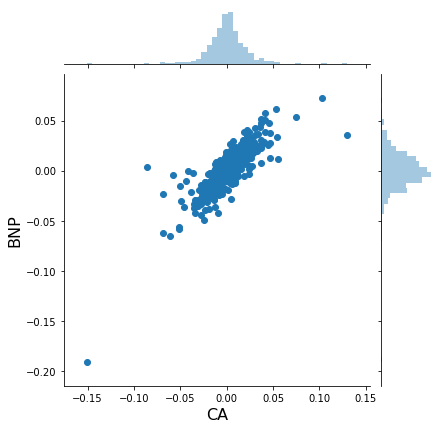

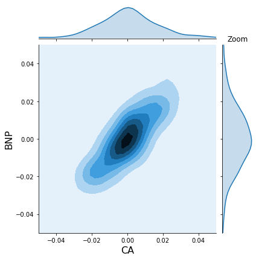

```python
h= sns.jointplot(x= ca_returns,y=bnp_returns,kind='scatter')
h.set_axis_labels('CA', 'BNP', fontsize=16);

h= sns.jointplot(x= ca_returns,y=bnp_returns,kind='kde',xlim=[-0.05,0.05],ylim=[-0.05,0.05])
h.set_axis_labels('CA', 'BNP', fontsize=16)
plt.title("Zoom")
plt.show()
```

Il y a une corrélation positive des rendements.

```python
from statsmodels.distributions.empirical_distribution import ECDF

ca_cdf = ECDF(ca_returns)
bnp_cdf = ECDF(bnp_returns)
```

Voici ci-dessous la fonction de répartition jointe, représentation usuelle des copules.

Les distributions marginales sont bien uniformes, ce qui défini une copule.

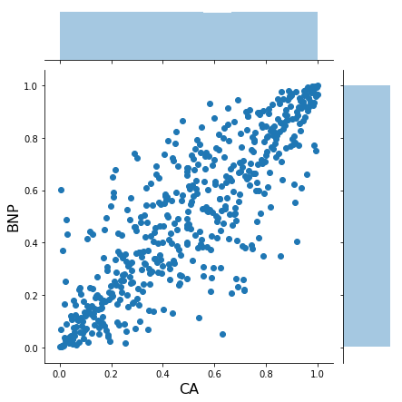

```python
h= sns.jointplot(x= ca_cdf(ca_returns),y=bnp_cdf(bnp_returns),kind='scatter')
h.set_axis_labels('CA', 'BNP', fontsize=16)

plt.show()
```

La structure de corrélation semble être symétrique selon la queue de distribution.

**Copule Gaussienne**

Créons une copule gaussienne depuis un tirage de gaussienne bivariée.

```python
from scipy import stats

returns = pd.concat([ca_returns,bnp_returns],axis=1)
mv_norm = stats.multivariate_normal(mean= np.mean(returns,axis=0),cov= returns.corr())
mv_norm_spl = mv_norm.rvs(returns.shape[0]*100)
```

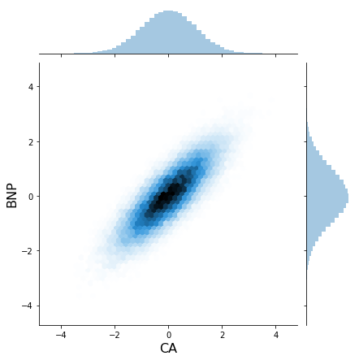

```python
h= sns.jointplot(x= mv_norm_spl[:,0],y= mv_norm_spl[:,1],kind='hex')
h.set_axis_labels('CA', 'BNP', fontsize=16);

plt.show()
```

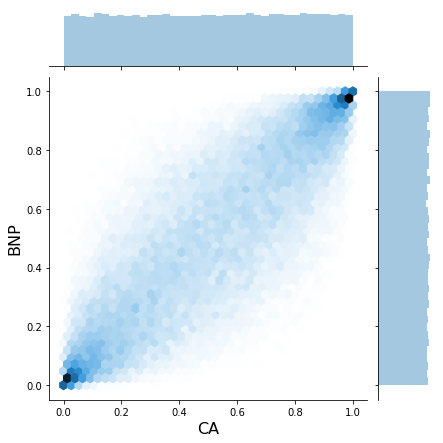

```python
norm = stats.norm()
mv_norm_spl_unif = norm.cdf(mv_norm_spl)

h = sns.jointplot(mv_norm_spl_unif[:, 0], mv_norm_spl_unif[:, 1], kind='hex')
h.set_axis_labels('CA', 'BNP', fontsize=16)

plt.show()
```

La structure de dépendance est symmétrique dans les queues

**module Copulae**

On considère maintenant la copule de Gumbel, qui permet une faible corrélation de queue gauche.

```python
c1 = copulae.archimedean.GumbelCopula(dim=2)
c1.fit(data=returns)
c1.summary()
```

gumbel Copula Summary

gumbel Copula with 2 dimensions

Parameters

**theta**2.7233170771252655

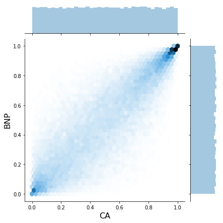

```python
c1_cdf = c1.random(n=returns.shape[0]*100)
h = sns.jointplot(c1_cdf[:, 0],c1_cdf[:, 1], kind='hex')
h.set_axis_labels('CA', 'BNP', fontsize=16);
```

**Calcul de la VaR**

*Les portefeuilles sont équipondérés par les prix (même nombre d'actions par entreprise)*

Portefeuille Empirique

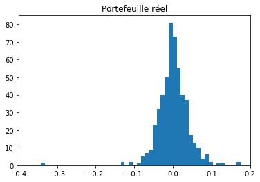

```
Skewness: -0.9747186164584692
Kurtosis: 12.227033324154064
```

```python
from scipy.stats import kurtosis, skew

pf_reel = returns.sum(axis=1)
plt.hist(pf_reel,bins=50)
plt.xlim([-0.4,0.2])
plt.title("Portefeuille réel")
plt.show()

print("Skewness: {} \nKurtosis: {}".format(skew(pf_reel),kurtosis(pf_reel)))
```

Portefeuille avec copule de Gumbel

*On suppose que les distributions marginales (les rendements individuels) sont normales !*

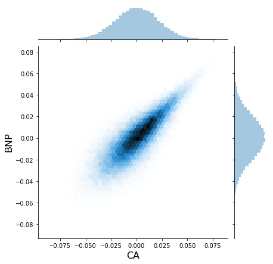

```python
m1 = stats.norm(loc=ca_returns.mean(),scale=ca_returns.std())
m2 = stats.norm(loc=bnp_returns.mean(),scale=bnp_returns.std())

ca_returns_m1 = m1.ppf(c1_cdf[:, 0])
bnp_returns_m2 = m2.ppf(c1_cdf[:, 1])

h = sns.jointplot(ca_returns_m1,bnp_returns_m2, kind='hex')
h.set_axis_labels('CA', 'BNP', fontsize=16)

plt.show()
```

La copule modélise bien une distribution jointe (de gaussiennes) à structure de corrélation assymétrique.

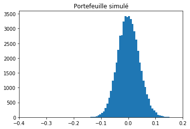

```
Skewness: 0.10199439397559272
Kurtosis: 0.021726600851515787
```

```python
returns_c1 = pd.DataFrame(np.vstack([ca_returns_m1,bnp_returns_m2]).T)
pf_c1 = returns_c1.sum(axis=1)
plt.hist(pf_c1,bins=50)
plt.xlim([-0.4,0.2])
plt.title("Portefeuille simulé")
plt.show()


print("Skewness: {} \nKurtosis: {}".format(skew(pf_c1),kurtosis(pf_c1)))
```

les queues sont bien moins épaisses par rapport au réel.

Les VaR

```python
def vars(percentile,pf_c):
    var_reel = -1 * np.percentile(pf_reel, percentile)
    var_c = -1 * np.percentile(pf_c, percentile)
    return var_reel,var_c
```

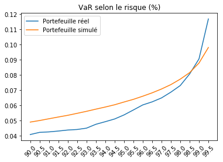

```python
VaRs = pd.DataFrame([vars(i,pf_c1) for i in np.linspace(0.5,10,(10/0.5))],
                    columns=['réel','simulé'],
                    index= 100 - np.linspace(0.5,10,(10/0.5)))

plt.plot(VaRs['réel'],label='Portefeuille réel')
plt.plot(VaRs['simulé'],label='Portefeuille simulé')
plt.title('VaR selon le risque (%)')
plt.xticks(100 - np.linspace(0.5,10,(10/0.5)))
plt.xticks(rotation=45)
plt.legend()
plt.show()
```

La copule de Gumbel donne logiquement une VaR inférieure à risque faible par rapport au réel. L'idée que les chocs négatifs sont idiosyncratiques est irréel.

Une copule de Clayton ou de Frank donnerait une VaR sûrement plus proche du portefeuille réel.

De plus, nous sommes maintenant coutûmiers du fait, modéliser les rendements individuels par des gaussiennes est incorrect. Des distributions plus épaisses dans les queues représentent mieux les séries financières.

On peut par exemple utiliser des students ou des lois stables.

**Copule de Clayton et loi de student**

```python
c2 = copulae.archimedean.ClaytonCopula(dim=2)
c2.fit(data=returns)
c2.summary()
```

clayton Copula Summary

clayton Copula with 2 dimensions

Parameters

**theta**2.4177754076131914

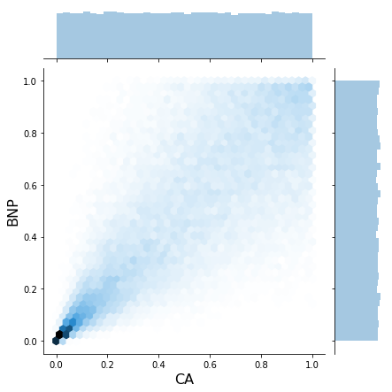

```python
c2_cdf = c2.random(n=returns.shape[0]*100)
h = sns.jointplot(c2_cdf[:, 0],c2_cdf[:, 1], kind='hex')
h.set_axis_labels('CA', 'BNP', fontsize=16);
```

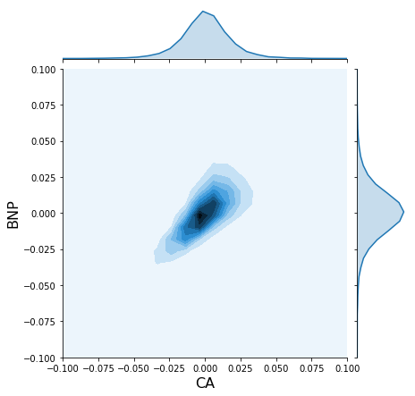

```python
l1 = stats.t.fit(ca_returns)
l2 = stats.t.fit(bnp_returns)

l1 = stats.t(l1[0],l1[1],l1[2])
l2 = stats.t(l2[0],l2[1],l2[2])

ca_returns_l1 = l1.ppf(c2_cdf[:, 0])
bnp_returns_l2 = l2.ppf(c2_cdf[:, 1])

h = sns.jointplot(ca_returns_l1,bnp_returns_l2, kind='kde')
h.set_axis_labels('CA', 'BNP', fontsize=16)
h.ax_marg_x.set_xlim(-0.1,0.1)
h.ax_marg_y.set_ylim(-0.1,0.1)
plt.show()
```

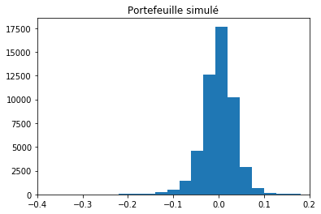

```
Skewness: -0.7025874731809285
Kurtosis: 12.666676199016882
```

```python
returns_c2 = pd.DataFrame(np.vstack([ca_returns_l1,bnp_returns_l2]).T)
pf_c2 = returns_c2.sum(axis=1)
plt.hist(pf_c2,bins=50)
plt.xlim([-0.4,0.2])
plt.title("Portefeuille simulé")
plt.show()


print("Skewness: {} \nKurtosis: {}".format(skew(pf_c2),kurtosis(pf_c2)))
```

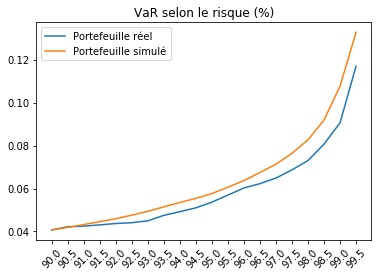

```python
VaRs = pd.DataFrame([vars(i,pf_c2) for i in np.linspace(0.5,10,(10/0.5))],
                    columns=['réel','simulé'],
                    index= 100 - np.linspace(0.5,10,(10/0.5)))

plt.plot(VaRs['réel'],label='Portefeuille réel')
plt.plot(VaRs['simulé'],label='Portefeuille simulé')
plt.title('VaR selon le risque (%)')
plt.xticks(100 - np.linspace(0.5,10,(10/0.5)))
plt.xticks(rotation=45)
plt.legend()
plt.show()
```

Cette fois, la VaR simulée est bien supérieure à l'empirique.

L'interêt des copules pour la simulation de données multivariées à structure spécifique de dépendance est très intéressant. La modulation de la VaR en fonction de la copule et des lois marginales de rendement donnent à réfléchir quant à la modélisation de la VaR réglémentaire bâloise.